# 36-315 Homework 04, Fall 2016

Solutions

Due Wednesday, September 28, 2016 (12pm ET) on Blackboard

## Homework 04: Mosaic Plots and Continuous Data

# Problem 1

**Critiquing Graphs**:

See previous examples

# Problem 2

**Mosaic Plots vs. Stacked Bar Charts**

Mosaic plots plot and stacked bar charts both show the marginal distribution of one variable on the x-axis, along with the distribution of a second variable on the y-axis conditional on the first. Both graphs also use relative bar heights on the y-axis in order to display the conditional distributions.

The widths of the bars in a mosaic plots are proportional to the marginal distribution of the variable plotted on the x-axis, while they have no meaning in the stacked bar chart. In mosaic plots, the y-axis shows the proportions of the conditional distribution rather than the total counts. The overall heights of the bars are the same in a mosaic plot, while they differ in a stacked bar chart. Thus, cell counts are proportional to height in the stacked bar chart, but to the area of the boxes in the mosaic plot. Mosaic plots are also colored based on the standardized residuals of a Pearson chi-squared test for independence for each category, while stacked bar charts are colored based on the identification of each category within each stacked bar.

# Problem 3

**Mosaic Plot vs. Stacked Bar Chart vs. Side-by-Side Bar Chart**

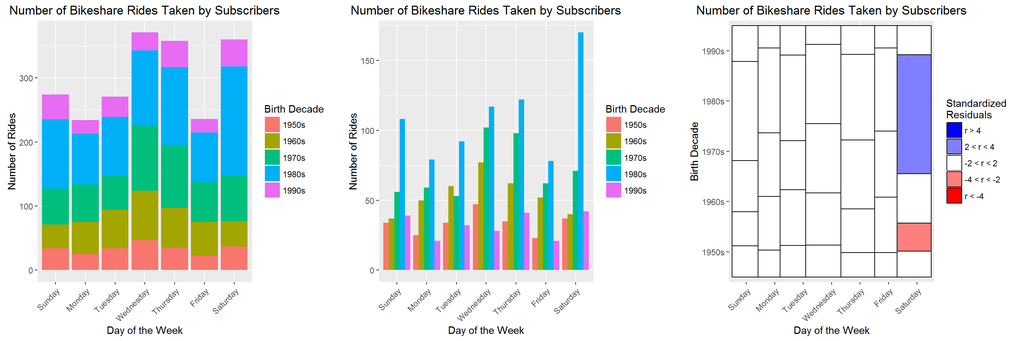

```r
library(data.table)
library(ggplot2)
library(reshape2)
library(gridExtra)
library(dplyr)
library(devtools)
source_url("https://raw.githubusercontent.com/sventura/315-code-and-datasets/master/code/geom_mosaic.R")

bike_data <- fread("https://raw.githubusercontent.com/sventura/315-code-and-datasets/master/data/nyc-citi-bike-data-subset.csv")
date_time <- colsplit(bike_data$starttime, " ", c("date", "time"))
bike_data <- mutate(bike_data,
                    birth_decade = paste0(substr(`birth year`, 1, 3), "0s"),
                    date = as.vector(date_time$date),
                    time_of_day = as.vector(date_time$time),
                    hour_of_day = substr(time_of_day, 1, 2),
                    am_or_pm = ifelse(as.integer(hour_of_day) < 12, "AM", "PM"),
                    day_of_week = weekdays(as.Date(date, format = "%m/%d/%Y")),
                    less_than_30_mins = ifelse(tripduration < 1800,
                                               "Short Trip", "Long Trip"),
                    weekend = ifelse(day_of_week %in% c("Saturday", "Sunday"),
                                     "Weekend", "Weekday"))

bike_data$day_of_week <-
  factor(bike_data$day_of_week,
         levels= c("Sunday", "Monday", "Tuesday", "Wednesday",
                   "Thursday", "Friday", "Saturday"))

bike_data_subset <- filter(bike_data,
                        usertype != "Customer",
                        `birth year` >= 1950)

day_decade_stacked <- ggplot(data = bike_data_subset) +
  geom_bar(aes(x = day_of_week, fill = birth_decade)) +
  labs(x = "Day of the Week", y = "Number of Rides", fill = "Birth Decade",
       title = "Number of Bikeshare Rides Taken by Subscribers") +
  theme(axis.text.x = element_text(angle = 45, hjust = 1))

day_decade_side <- ggplot(data = bike_data_subset) +
  geom_bar(aes(x = day_of_week, fill = birth_decade), position = "dodge") +
  labs(x = "Day of the Week", y = "Number of Rides", fill = "Birth Decade",
       title = "Number of Bikeshare Rides Taken by Subscribers") +
  theme(axis.text.x = element_text(angle = 45, hjust = 1))

day_decade_mosaic <- ggplot(data = bike_data_subset) +
  geom_mosaic(aes(x = day_of_week, y = birth_decade)) + mosaic_legend() +
  labs(x = "Day of the Week", y = "Birth Decade",
       title = "Number of Bikeshare Rides Taken by Subscribers") +
  theme(axis.text.x = element_text(angle = 45, hjust = 1))

grid.arrange(day_decade_stacked, day_decade_side,day_decade_mosaic, nrow = 1)
```

The stacked bar chart allows us to look at the marginal distribution of day of week more easily since we can see the total count within each category, but makes it harder to compare the conditional distributions of birth decade given day of week. The side by side plot makes it easier to compare the conditional distributions of decade given day of week since we can see the individual counts of decade for each day of the week, but makes it harder to see the marginal distribution of day of week. The mosaic plot shows both the joint distribution and the marginal distribution of day of week well, but the coloring scheme – while providing us with useful information about the result of a statistical test (the chi-square test) – makes it harder to differentiate between the different categories, especially if/when some combinations of categories have no observations.

The stacked bar chart is easiest to see the marginal distribution of day of week. The side by side bar chart is easiest to see the conditional distribution of decade given day of week. The mosaic plot best displays the outcome of a statistical test, such as the chi-squared test for independence.

The graph I like the most is dependent on the goal of my graphic or what I am most interested in seeing. If I care most about the conditional distribution of the second variable given the first, I would choose the side-by-side bar plot. If I care most about the marginal distribution of the first variable, I would choose a stacked bar plot. If I cared about the joint distribution of the two variables or the proportional distribution of the conditional distribution of the second variable given the first or testing for independence, I would choose the mosaic plot.

# Problem 4

**Pittsburgh Bridges**

```r
bridge_data <- fread("https://raw.githubusercontent.com/sventura/315-code-and-datasets/master/data/bridges-pgh.csv")
```

```r
#str(bridge_data)
```

The river, purpose, material, span, and type are all categorical. River is whether it goes over the Allegheny, Ohio, or Monongahela Rivers, the purpose is split by whether the bridge was built as part of a highway, railroad, or for an aqueduct, and the span determines whether the bridge is short, medium, or long in length. The materials that the bridges could have been built with are wood, iron, or steel, and the type of bridge is split by wooden, suspension, simple-t, arch, cantilever, and cont-t. Lanes are numerical, and since there are only four possible values in this dataset – 1, 2, 4, or 6 lane bridges – it makes the most sense to treat this variable categorically.

```r
#min(when.erected)
#max(when.erected)

#min(lanes)
#max(lanes)

#min(length)
#max(length)
```

The year erected and length can be considered continuous. The year is between 1819 and 1978, and the length is between 840 and 4558 feet. I consider the year to be continuous, since it can take on all integer values and because considering it as a categorical variable would create many small categories, which would not tell us much in our analysis. Additionally, time is measured continuously, and the integer-valued year is just some function of the continuously measured time. We could change it to a categorical variable if we grouped in to decades or some other range of years.

3. *These are only examples. Your own answers may vary.*

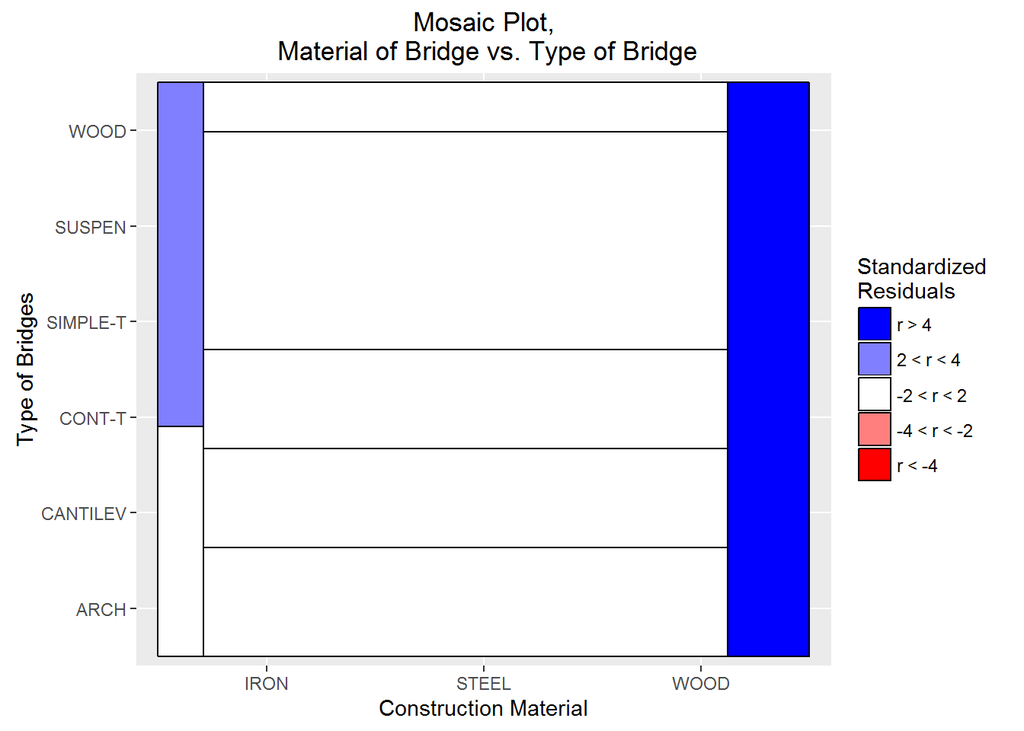

```r
#Material vs. type
ggplot(data = bridge_data) +
  geom_mosaic(aes(x = material, y = type)) + mosaic_legend() +
  ggtitle("Mosaic Plot,\n Material of Bridge vs. Type of Bridge") +
  labs(x = "Construction Material", y = "Type of Bridges")
```

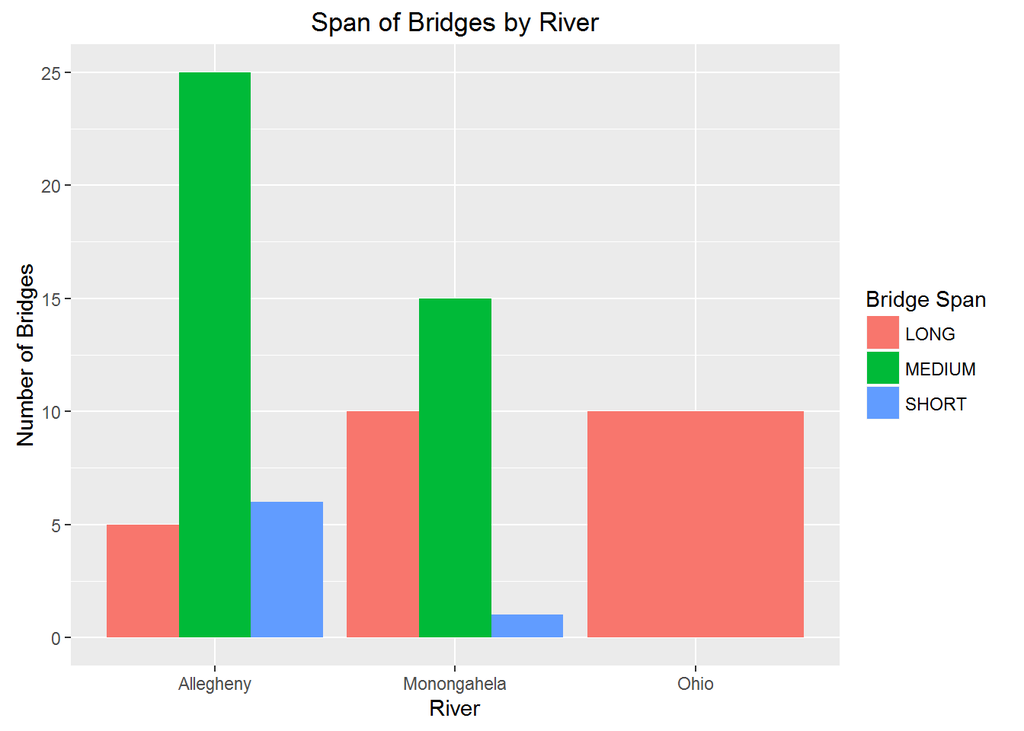

```r
#River vs. Length
bridge_data$river_full <- factor(bridge_data$river,
                                 labels = c("Allegheny", "Monongahela", "Ohio"))

ggplot(data = bridge_data) + geom_bar(aes(x = river_full, fill = span),
                                      position = position_dodge()) +
  ggtitle("Span of Bridges by River") +
  labs(x = "River", y = "Number of Bridges", fill = "Bridge Span")
```

Bridges over the Allegheny River are a lot less likely to have a long span, and are more likely to have both short or a medium span compared to the other two rivers, Bridges over the Ohio River are only long in span. Bridges over the Monongahela are fairly evenly split between long and medium spans, with only a few short spans. It would seem as the Ohio is the widest river of the three, while the Allegheny River is the narrowest.

The Liberty Bridge recently caught on fire and has been closed ever since. It is row 46 in the data set. We figured this out by looking up the length of the bridge and the year in which it was erected on the internet, and comparing these values to those in the dataset.

Update: The bridge has now reopened!

# Problem 5

(4 points each)

**Introduction to Continuous Data – Box Plots**

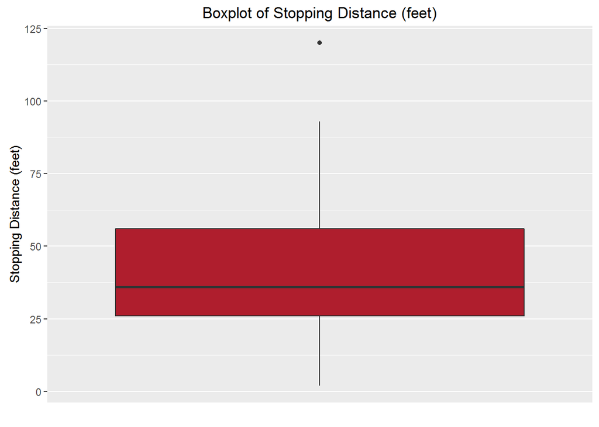

```r
library(datasets)
data(cars)

ggplot(data = cars) + aes(factor(1), dist) +
  geom_boxplot(fill = "#AF1E2D") +
  ggtitle("Boxplot of Stopping Distance (feet)") +
  labs(x = "", y = "Stopping Distance (feet)") +
  scale_x_discrete(breaks = NULL)
```

# Problem 6

(3 points each)

**Critiquing Boxplots**

1. Many of the choices in the definition of outliers of boxplots are ambiguous: why it uses the median instead of the mean, why the IQR, and why 1.5*IQR determines the threshold for outliers. This definition for outliers is not fair for skewed distributions that do no have symmetric, bell shaped curves. Additionally, why do we care about the 25th and 75th quantiles as opposed to some other values? Etc.
2. You should preserve the lines indicating range, median and quartiles. You could also mark more quantiles of the distribution or have the flexibility to change how outliers are defined. You could show the distribution instead of a flat plot, like in box-percentile plots (we’ll discuss these later). And with a box-percentile plot (or some other visualization of distribution), we would be able to assess modality.

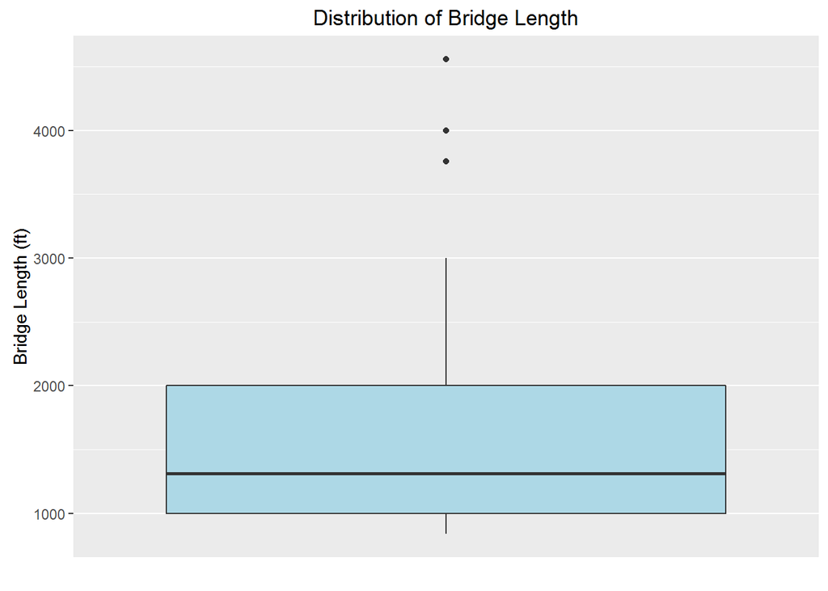

```r
# Create a boxplot of the length variable

ggplot(data = bridge_data, aes(factor(""), length)) +
  geom_boxplot(fill = "lightblue") +
  ggtitle("Distribution of Bridge Length") +
  ylab("Bridge Length (ft)") +
  xlab("") +
  scale_x_discrete(breaks = NULL)
```

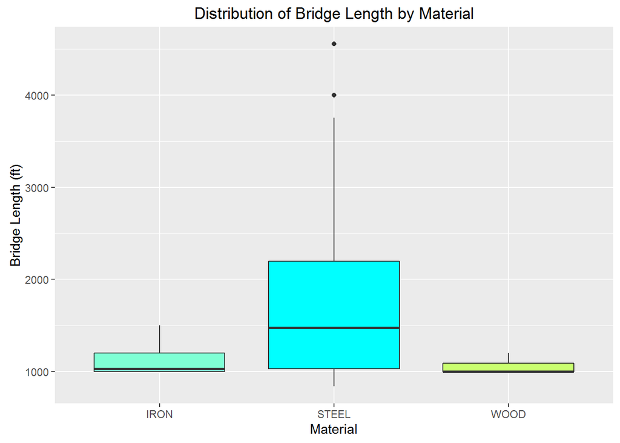

```r
ggplot(data = bridge_data, aes(x = material, y = length)) +
  geom_boxplot(fill = c("aquamarine", "cyan", "darkolivegreen1")) +
  ggtitle("Distribution of Bridge Length by Material") +
  ylab("Bridge Length (ft)") +
  xlab("Material")
```

We can see that iron and wood bridges are much shorter than bridges of steel, and these two both also have right skewed distributions. The distribution of steel bridges is still slightly skewed right, and has two outliers. The range of lengths of steel bridges is very large. We cannot compare the modality of these distributions.

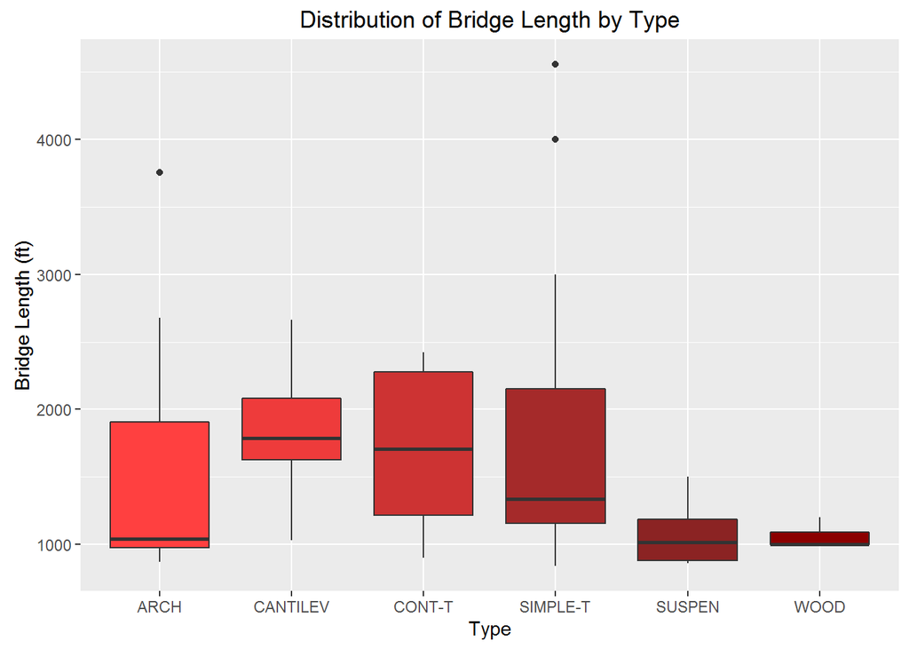

```r
ggplot(data = bridge_data, aes(x = type, y = length)) +
  geom_boxplot(fill = c("brown1", "brown2", "brown3", "brown", "brown4", "darkred"))+
  ggtitle("Distribution of Bridge Length by Type") +
  ylab("Bridge Length (ft)") +
  xlab("Type")
```

The distributions of cantilever, cont-T, and suspension bridges seem fairly symmetric and have no potential outliers. The distributions of arch and simple-T bridges have large ranges, are right skewed, and have outliers in the upper tails. The distribution of wood bridges is much more compact, comparatively.

# Problem 7

(3 points each)

**Histograms**

1. Create a histogram of the `length` variable. Use 20 equally sized bins – you can specify this with `bins = 20` in your call to `geom_histogram()`. Be sure that your graph is properly labeled and titled.

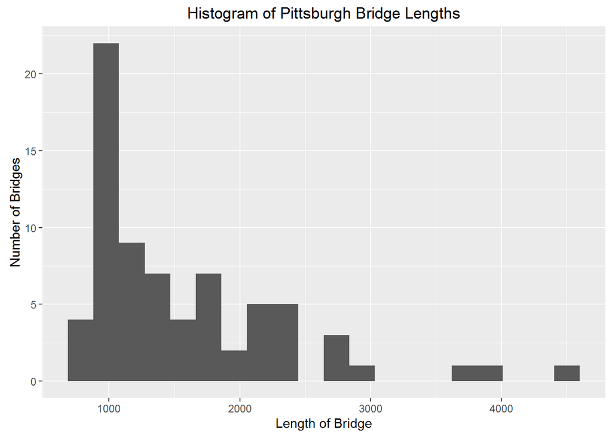

```r
ggplot(data = bridge_data, aes(x = length)) +
  geom_histogram(bins = 20) + ylab("Number of Bridges") +
  xlab("Length of Bridge") + ggtitle("Histogram of Pittsburgh Bridge Lengths")
```

2. Repeat part (a), but this time, in your call to `geom_histogram()`, include `aes(fill=..count..)`. What does this do to the graph?

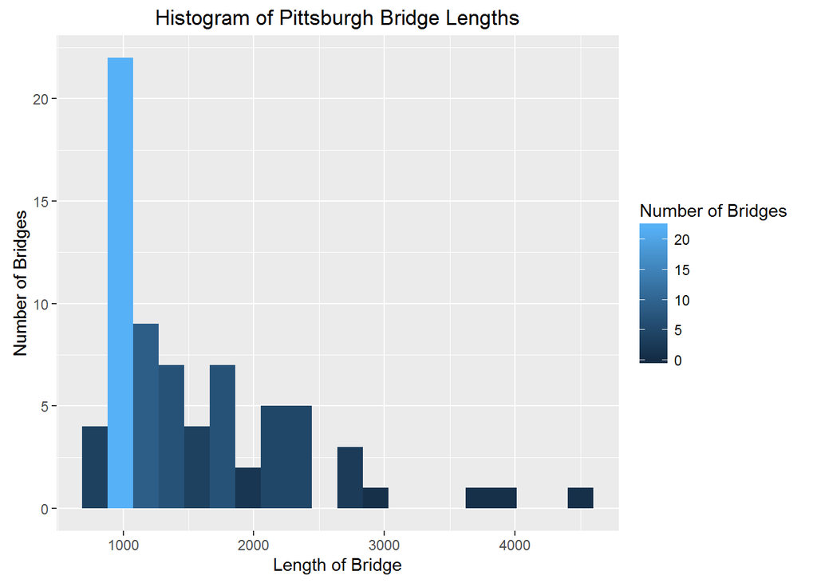

```r
ggplot(data = bridge_data, aes(x = length)) +
  geom_histogram(aes(fill=..count..), bins = 20) + ylab("Number of Bridges") +
  xlab("Length of Bridge") + ggtitle("Histogram of Pittsburgh Bridge Lengths") +
  scale_fill_continuous(name = "Number of Bridges")
```

Adding `aes(fill=..count..)` to the `geom_histogram()` call colors the each bin of the histogram according to the number of bridges contained within it on a continuous color scale. The `..count..` object is calculated during your call to `geom_histogram()`; it specifies the count in each bin of the histogram.

3. Repeat part (b), but this time, add `+ scale_fill_gradient("Legend Label", low = "green", high = "red")` to the line of code. Use an appropriate legend label. Try a few different combinations of colors. What does `scale_fill_gradient()` do?

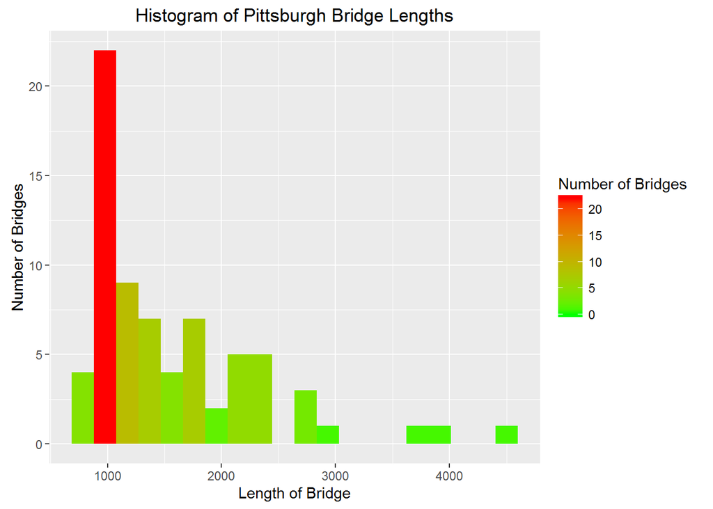

```r
ggplot(data = bridge_data, aes(x = length)) +
  geom_histogram(aes(fill=..count..), bins = 20) + ylab("Number of Bridges") +
  xlab("Length of Bridge") + ggtitle("Histogram of Pittsburgh Bridge Lengths") +
  scale_fill_gradient("Number of Bridges", low = "green", high = "red")
```

`scale_fill_gradient()` sets the color scale used by fill argument. Setting the `low` and `high` arguments sets the range of colors used

4. Create a bar chart of the `when.erected` variable. Use proper labels/titles/colors.

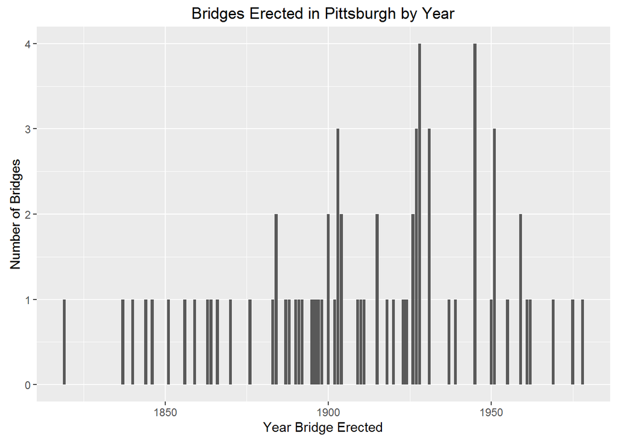

```r
ggplot(data = bridge_data, aes(x = when.erected)) +
  geom_bar() + ylab("Number of Bridges") +
  xlab("Year Bridge Erected") + ggtitle("Bridges Erected in Pittsburgh by Year")
```

5. Create a histogram of the `when.erected` variable. Use proper labels/titles/colors. Using the same approach as we did in Lab 04, specify `binwidth = 1`. Compare this graph to the graph in (d).

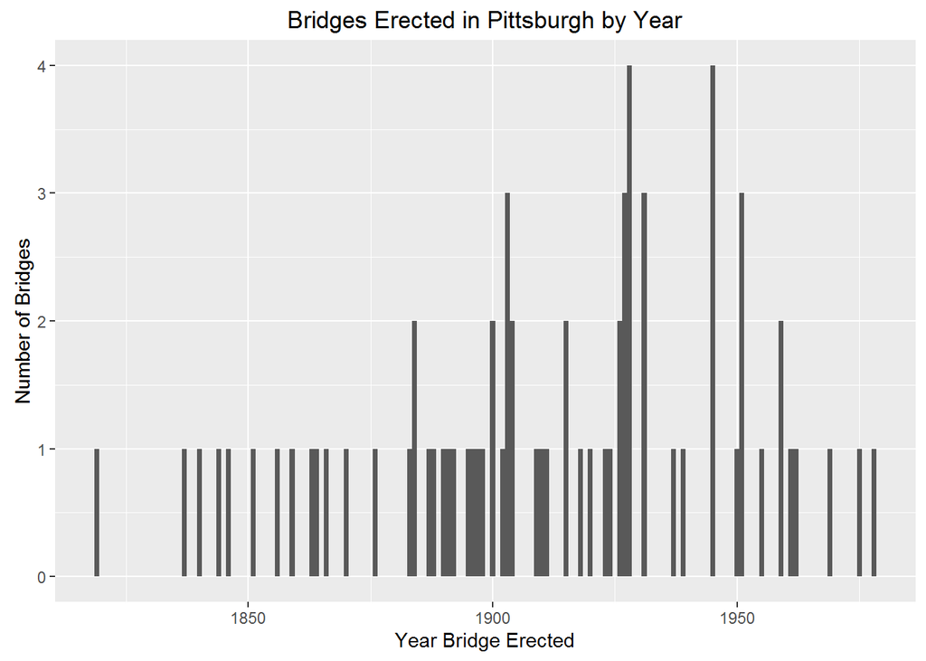

```r
ggplot(data = bridge_data, aes(x = when.erected)) +
  geom_histogram(binwidth = 1) + ylab("Number of Bridges") +
  xlab("Year Bridge Erected") + ggtitle("Bridges Erected in Pittsburgh by Year")
```

This looks the same as the graph in (d) because a histogram with a different bin for each value is the same as a bar chart.

Notice that with the bar chart, there is one particular issue: If the year variable is stored as a factor, then for any year has no bridges built, then there will not be a bar for this year, since the bar chart treats the years categorically. In these cases, the scale on the x-axis is distorted, since it skips over (ranges of) years. For example, see the graph below:

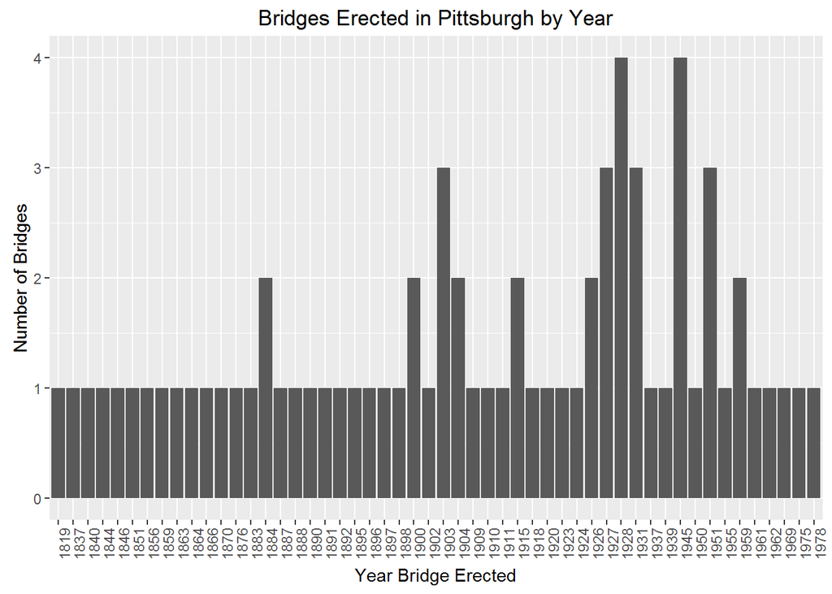

```r
ggplot(data = bridge_data, aes(x = as.factor(when.erected))) +
  geom_bar() + ylab("Number of Bridges") +
  xlab("Year Bridge Erected") + ggtitle("Bridges Erected in Pittsburgh by Year") +
  theme(axis.text.x = element_text(angle = 90, hjust = 1))
```

You might say, “But Sam, the year isn’t stored as a factor here!” While that’s true, this is because Sam formatted the input dataset so that you wouldn’t run into this issue. In the real-world, depending on the format of the input dataset and the functions you use to read the data in, you will often encounter situations where variables with numeric values are stored as strings or factors, causing issues when plotting the data.

6. Change the `binwidth` to something more appropriate (e.g. 10), in order to smooth out the distribution. Describe the marginal distribution of `when.erected`. In what decades were the most Pittsburgh bridges built?

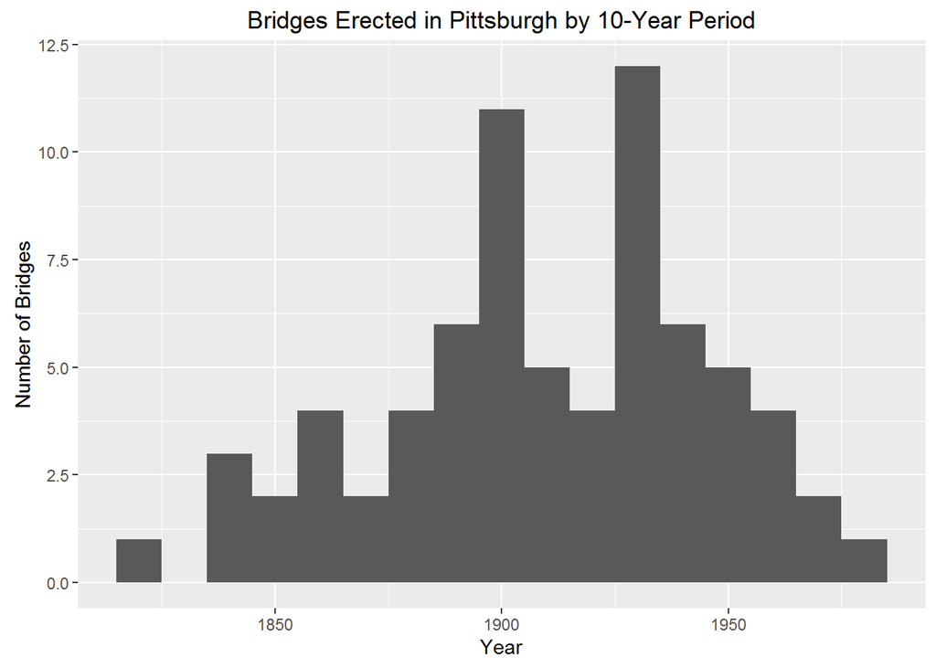

```r
ggplot(data = bridge_data, aes(x = when.erected)) +
  geom_histogram(binwidth = 10) + ylab("Number of Bridges") +
  xlab("Year") +
  ggtitle("Bridges Erected in Pittsburgh by 10-Year Period")
```

The historical pace of bridge construction in Pittsburgh appears bimodal with peaks in the period from 1895 - 1905 and from 1925 - 1935. There is some variation in other periods but outside of those two 10-year periods the average pace appears to be around 2.5 bridges per decade although there has been a decline from 1950 until the present.

Note that we can easily change the bin width to something like 5 years (as below) and still answer the question about decades (perhaps even more effectively).

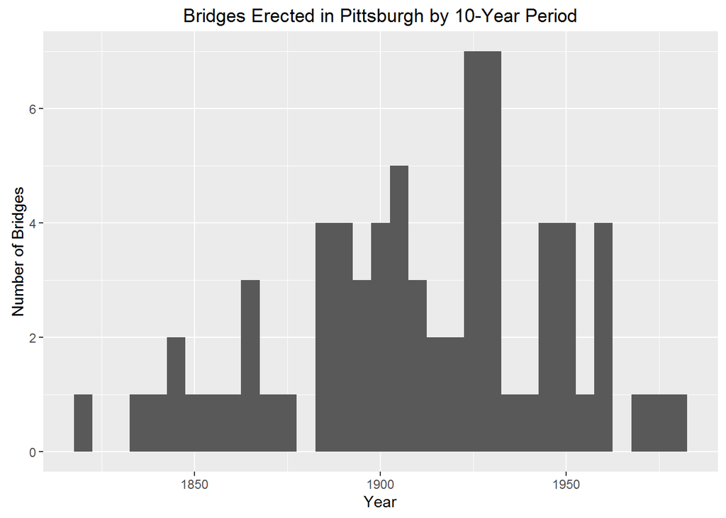

```r
ggplot(data = bridge_data, aes(x = when.erected)) +
  geom_histogram(binwidth = 5) + ylab("Number of Bridges") +
  xlab("Year") +
  ggtitle("Bridges Erected in Pittsburgh by 10-Year Period")
```

7. Use the `facet_wrap()` or `facet_grid()` functions to visualize the conditional distribution of the `when.erected` variable given `material`. Describe and compare the different conditional distributions of `when.erected` given `material`. Describe any relationship between these two variables that you observe.

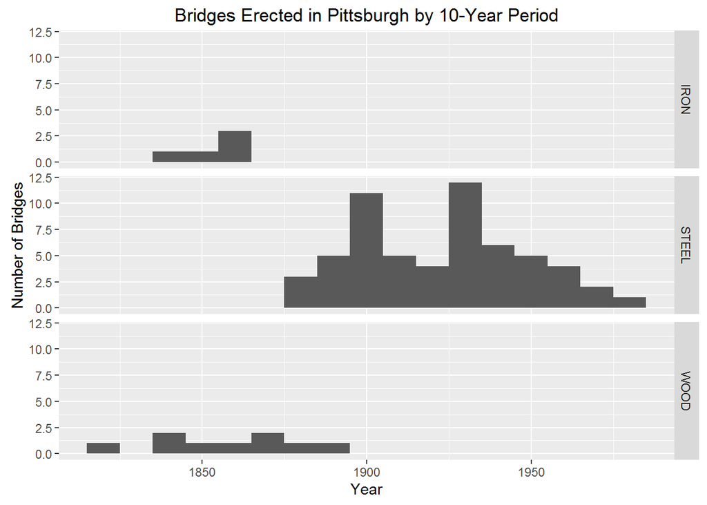

```r
ggplot(data = bridge_data, aes(x = when.erected)) +
  geom_histogram(binwidth = 10) + ylab("Number of Bridges") +
  xlab("Year") +
  ggtitle("Bridges Erected in Pittsburgh by 10-Year Period") +
  facet_grid(material~.)
```

First note that the majority of the bridges built in Pittsburgh were made of steel. A few iron bridges were built around 1850 and into the 1860s. Similarly, several wooden bridges were built in the mid to late 1800s. However, all bridges built since 1900 have been made of steel.

Note that we strongly prefer using `facet_grid()`, and in particular, we strongly prefer organizing these graphs vertically. The reason for this is that it’s much easier to compare these conditional distributions when they’re displayed vertically as opposed to horizontally – it’s very easy for our eyes to look up and down the graphs and compare the locations of the bars, since the graphs use the same x-axis scale.

8. (BONUS: 2 points) What local, national, and world events might have contributed to Pittsburgh’s increases and decreases in bridge construction since 1800?

The boom in bridge construction in the period from 1925 - 1935 and subsequent collapse afterwards was likely linked to the economic boom in the 1920s and economic collapse of the great depression.

There are additional factors that contributed to bridge construction in Pittsburgh: The boom in the steel industry as a result of the different wars is a big reason. Steel and iron mills were extremely common up and down Pittsburgh’s rivers and on both shores, so bridges were needed to ease the transportation of people, materials, and other goods.

# Problem 8

(5 points)

**Themes in `ggplot`**

Read the documentation on `ggplot` themes [here](http://docs.ggplot2.org/dev/vignettes/themes.html).

Pick one of your graphs from Problem 7, and recreate it with a new theme. In your new theme, use a white background, a different font style, a different font size, a different font color, and any additional changes that you choose.

Use the example code in the above documentation if you have trouble.

Note: Starting with Lab05 and continuing for every Lab and Homework assignment for the remainder of the course, you are required to use your own personal graph theme for all `ggplot()` graphics that you create. We’ll discuss this more next week!

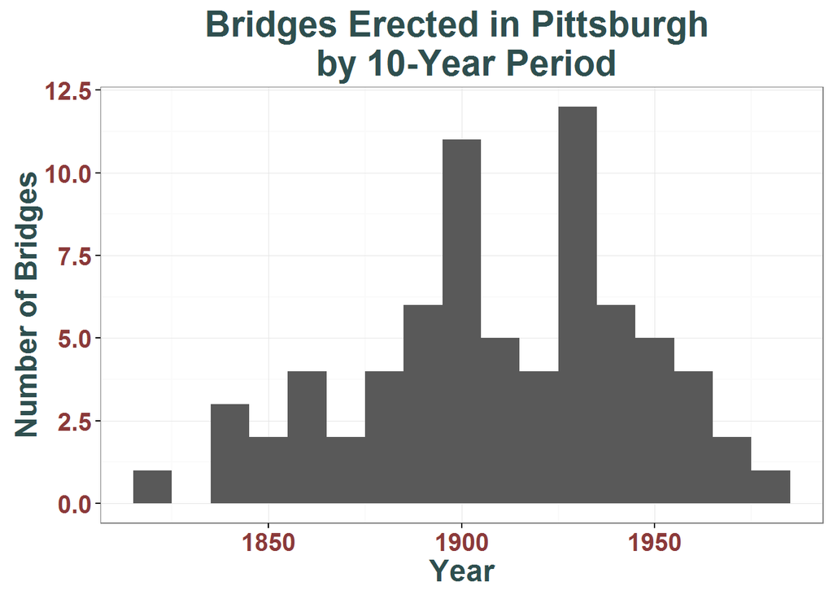

```r
#Create theme that can be added to plots
my_theme <-  theme_bw() + # White background, black and white theme
  theme(axis.text = element_text(size = 15, family = "Times", color="indianred4"),
        text = element_text(size = 18, family = "Times", face="bold", color="darkslategrey"))

ggplot(data = bridge_data, aes(x = when.erected)) +
  geom_histogram(binwidth = 10) + ylab("Number of Bridges") +
  xlab("Year") +
  ggtitle("Bridges Erected in Pittsburgh \n by 10-Year Period") + my_theme
```

Recreate the histogram from part (f).

- `theme_bw()` sets the background to black and white
- `axis.text = element_text(size = 15, family = "Times", color="indianred4")` used to set size, font, and color for axis tick labels
- `text = element_text(size = 18, family = "Times", face="bold", color="darkslategrey")` used to set size, font, and color for axis labels and title